# 202116927 오준석 SVM과 k-NN

202116927 오준석

2024-06-03

```r
library(dplyr)
```

```r
library(e1071)
library(ggplot2)
library(tidyr)
```

ULCA admission의 SVM과 k-NN ULCA 데이터의 모델을 만들기 위해 전처리를 진행

```r
ulca <- read.csv("binary.csv")
ulca$rank <- as.factor(ulca$rank)
ulca$admit <- as.factor(ulca$admit)
```

세 개의 변수가 합격에 미치는 영향을 알아보고자 함

```r
s <- svm(admit~., data=ulca)
print(s)
```

```
##
## Call:
## svm(formula = admit ~ ., data = ulca)
##
##
## Parameters:
##    SVM-Type:  C-classification
##  SVM-Kernel:  radial
##        cost:  1
##
## Number of Support Vectors:  267
```

```r
acc = table(predict(s, ulca), data=ulca$admit)
acc
```

```
##    data
##       0   1
##   0 260 100
##   1  13  27
```

```r
acc1 <- sum((acc["0", "0"]+acc["1", "1"])/sum(acc))
```

```r
s <- svm(admit~., data=ulca, kernal = "polynomial")
print(s)
```

```
##
## Call:
## svm(formula = admit ~ ., data = ulca, kernal = "polynomial")
##
##
## Parameters:
##    SVM-Type:  C-classification
##  SVM-Kernel:  radial
##        cost:  1
##
## Number of Support Vectors:  267
```

```r
acc = table(predict(s, ulca), data=ulca$admit)
acc
```

```
##    data
##       0   1
##   0 260 100
##   1  13  27
```

```r
acc2 <- sum((acc["0", "0"]+acc["1", "1"])/sum(acc))
```

radial basis 커널을 사용한 SVM과 polynomial 커널을 사용한 SVM의 정확도는 0.7175임.

```r
s <- svm(admit~., data=ulca, kernal = "polynomial", cost=100)
print(s)
```

```
##
## Call:
## svm(formula = admit ~ ., data = ulca, kernal = "polynomial", cost = 100)
##
##
## Parameters:
##    SVM-Type:  C-classification
##  SVM-Kernel:  radial
##        cost:  100
##
## Number of Support Vectors:  252
```

```r
acc = table(predict(s, ulca), data=ulca$admit)
acc
```

```
##    data
##       0   1
##   0 262  88
##   1  11  39
```

```r
acc3 <- sum((acc["0", "0"]+acc["1", "1"])/sum(acc))
```

```r
s <- svm(admit~., data=ulca, cost=100)
print(s)
```

```
##
## Call:
## svm(formula = admit ~ ., data = ulca, cost = 100)
##
##
## Parameters:
##    SVM-Type:  C-classification
##  SVM-Kernel:  radial
##        cost:  100
##
## Number of Support Vectors:  252
```

```r
acc = table(predict(s, ulca), data=ulca$admit)
acc
```

```
##    data
##       0   1
##   0 262  88
##   1  11  39
```

```r
acc4 <- sum((acc["0", "0"]+acc["1", "1"])/sum(acc))
```

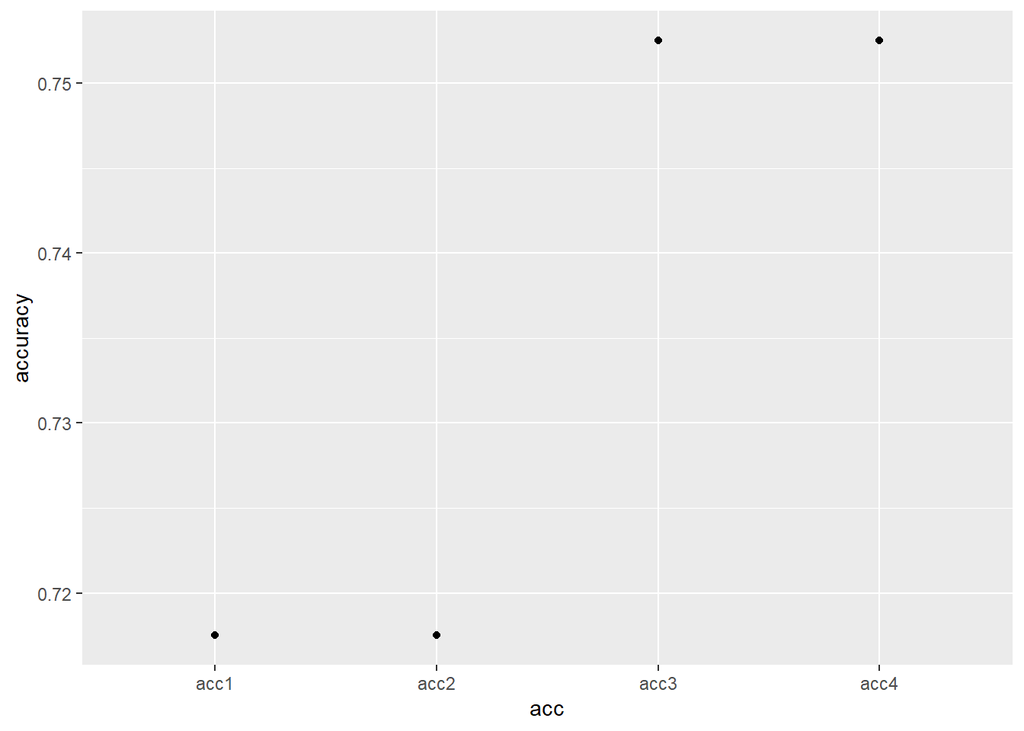

```r
accuracy <- data.frame(acc1, acc2, acc3, acc4)
accuracy <- accuracy%>%gather(key=acc, value=accuracy)
accuracy%>%ggplot(aes(acc, accuracy))+geom_point()
```

polynomial 커널을 사용하고 cost를 100으로 설정한 SVM과 radial basis 커널을 사용한 SVM의 정확도는 0.7525로, cost를 설정하지 않았을 때보다 4%가량의 정확도가 오름

```r
library(class)
library(caret)
train <- ulca
test <- data.frame(gre = c(800, 760, 540, 740), gpa = c(4.00, 3.52, 2.80, 3.75), rank = c("1", "4", "2", "3"))
k = knn(train[, 2:4], test, train$admit, k=5)
k
```

```
## [1] 1 1 0 0
## Levels: 0 1
```

ulca 데이터의 k-NN 모델을 k를 바꾸며 제작

```r
train <- ulca
n=400
ulca1 <- sample(1:n, size=n*3/4)
ulca_train <- ulca[ulca1, -1]
ulca_test <- ulca[-ulca1, -1]
trainLabels <- ulca[ulca1, 1]
testLabels <- ulca[-ulca1, 1]
k1 <- knn(ulca_train, ulca_test, trainLabels, k=1)
acc1 <- sum(k1==testLabels)/100
k2 <- knn(ulca_train, ulca_test, trainLabels, k=5)
acc2 <- sum(k2==testLabels)/100
k3 <- knn(ulca_train, ulca_test, trainLabels, k=10)
acc3 <- sum(k3==testLabels)/100
k4 <- knn(ulca_train, ulca_test, trainLabels, k=100)
acc4 <- sum(k4==testLabels)/100
```

제작한 모델의 정확성을 시각화

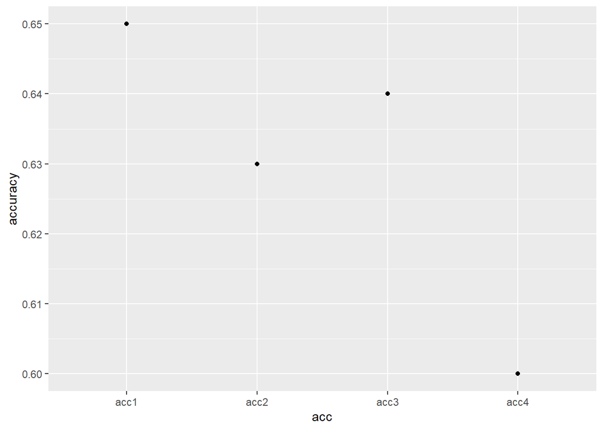

```r
accuracy <- data.frame(acc1, acc2, acc3, acc4)
accuracy <- accuracy%>%gather(key=acc, value=accuracy)
accuracy%>%ggplot(aes(acc, accuracy))+geom_point()
```

colon의 SVM과 k-NN colon 데이터의 모델을 만들기 위해 전처리

```r
library(survival)
colon <- colon[c(TRUE, FALSE), ]
colon <- colon[ , c(-1, -2, -15, -16)]
colon <- na.omit(colon)
colon$status <- as.factor(colon$status)
```

colon의 SVM

```r
s <- svm(status~. , data=colon)
print(s)
```

```
##
## Call:
## svm(formula = status ~ ., data = colon)
##
##
## Parameters:
##    SVM-Type:  C-classification
##  SVM-Kernel:  radial
##        cost:  1
##
## Number of Support Vectors:  713
```

```r
acc <- table(predict(s, colon), colon$status)
acc1 <- sum(acc["0", "0"]+acc["1", "1"])/sum(acc)
acc
```

```
##
##       0   1
##   0 364 178
##   1  94 252
```

```r
acc1
```

```
## [1] 0.6936937
```

```r
s <-svm(status~., data=colon, kernal='polynomial')
print(s)
```

```
##
## Call:
## svm(formula = status ~ ., data = colon, kernal = "polynomial")
##
##
## Parameters:
##    SVM-Type:  C-classification
##  SVM-Kernel:  radial
##        cost:  1
##
## Number of Support Vectors:  713
```

```r
acc <-table(predict(s, colon), colon$status)
acc2 <- sum(acc["0", "0"]+acc["1", "1"])/sum(acc)
acc
```

```
##
##       0   1
##   0 364 178
##   1  94 252
```

```r
acc2
```

```
## [1] 0.6936937
```

```r
s <- svm(status~., data=colon, cost=100)
print(s)
```

```
##
## Call:
## svm(formula = status ~ ., data = colon, cost = 100)
##
##
## Parameters:
##    SVM-Type:  C-classification
##  SVM-Kernel:  radial
##        cost:  100
##
## Number of Support Vectors:  616
```

```r
acc <- table(predict(s, colon), colon$status)
acc3 <- sum(acc["0", "0"]+acc["1", "1"])/sum(acc)
acc
```

```
##
##       0   1
##   0 401  76
##   1  57 354
```

```r
acc3
```

```
## [1] 0.8502252
```

```r
s <- svm(status~., data=colon, cost=100, kernal='polynomial')
print(s)
```

```
##
## Call:
## svm(formula = status ~ ., data = colon, cost = 100, kernal = "polynomial")
##
##
## Parameters:
##    SVM-Type:  C-classification
##  SVM-Kernel:  radial
##        cost:  100
##
## Number of Support Vectors:  616
```

```r
acc <- table(predict(s, colon), colon$status)
acc4 <- sum(acc["0", "0"]+acc["1", "1"])/sum(acc)
acc
```

```
##
##       0   1
##   0 401  76
##   1  57 354
```

```r
acc4
```

```
## [1] 0.8502252
```

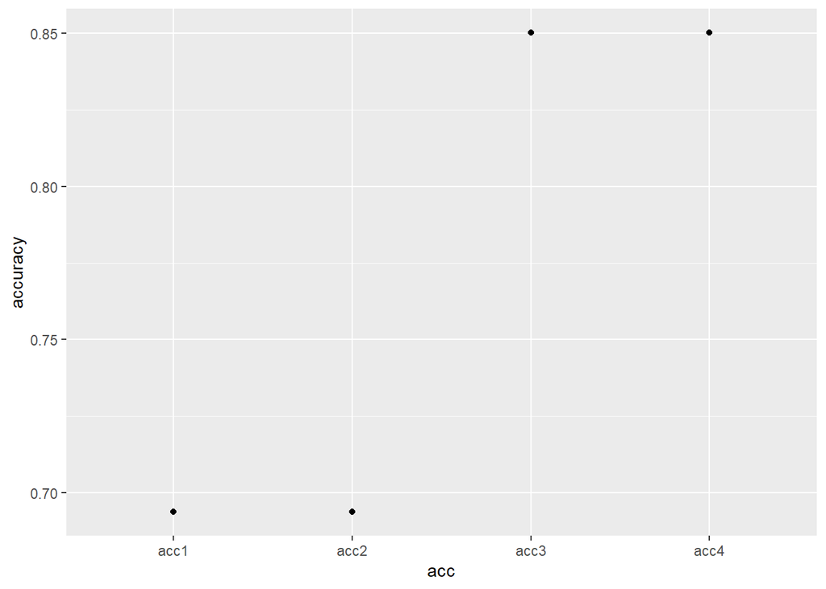

```r
accuracy <- data.frame(acc1, acc2, acc3, acc4)
accuracy <- accuracy%>%gather(key=acc, value=accuracy)
accuracy%>%ggplot(aes(acc, accuracy))+geom_point()
```

colon의 SVM에서 정확도는 커널의 종류와 관계 없고, cost가 100으로 설정되었을 때가 20%가량 높음

colon의 k-NN 모델을 만듦 여기서 rx는 범주형 변수로, 이를 이용해 k-NN 모델을 만든다면 수치형 데이터로 변환하는 과정에서 NA에 의한 오류가 발생함. 이를 해결하기 위해 치료를 진행하지 않았을 때인 obs를 0으로, 그 외의 범주를 1로 설정함.

```r
colon$rx <- ifelse(colon$rx=="obs", 0, 1)
train <- colon
str(colon)
```

```
## 'data.frame':    888 obs. of  12 variables:
##  $ rx      : num  1 1 1 1 1 1 1 1 1 1 ...
##  $ sex     : num  1 1 0 0 1 0 1 1 1 0 ...
##  $ age     : num  43 63 71 66 69 57 77 54 46 68 ...
##  $ obstruct: num  0 0 0 1 0 0 0 0 0 0 ...
##  $ perfor  : num  0 0 0 0 0 0 0 0 0 0 ...
##  $ adhere  : num  0 0 1 0 0 0 0 0 1 0 ...
##  $ nodes   : num  5 1 7 6 22 9 5 1 2 1 ...
##  $ status  : Factor w/ 2 levels "0","1": 2 1 2 2 2 2 2 1 1 1 ...
##  $ differ  : num  2 2 2 2 2 2 2 2 2 2 ...
##  $ extent  : num  3 3 2 3 3 3 3 3 3 3 ...
##  $ surg    : num  0 0 0 1 1 0 1 0 0 1 ...
##  $ node4   : num  1 0 1 1 1 1 1 0 0 0 ...
##  - attr(*, "na.action")= 'omit' Named int [1:41] 64 83 90 94 99 143 161 189 190 199 ...
##   ..- attr(*, "names")= chr [1:41] "127" "165" "179" "187" ...
```

```r
n=888
colon1 <- sample(1:n, size=3/4*n)
colon_train <- colon[colon1, -8]
colon_test <- colon[-colon1, -8]
trainLabels <- colon[colon1, 8]
testLabels <- colon[-colon1, 8]
k1 <- knn(colon_train, colon_test, trainLabels, k=1)
acc1 <- sum(k1==testLabels)/222
k2 <- knn(colon_train, colon_test, trainLabels, k=5)
acc2 <- sum(k2==testLabels)/222
k3 <- knn(colon_train, colon_test, trainLabels, k=10)
acc3 <- sum(k3==testLabels)/222
k4 <- knn(colon_train, colon_test, trainLabels, k=100)
acc4 <- sum(k4==testLabels)/222
```

k 값에 따른 정확성을 시각화, 평가

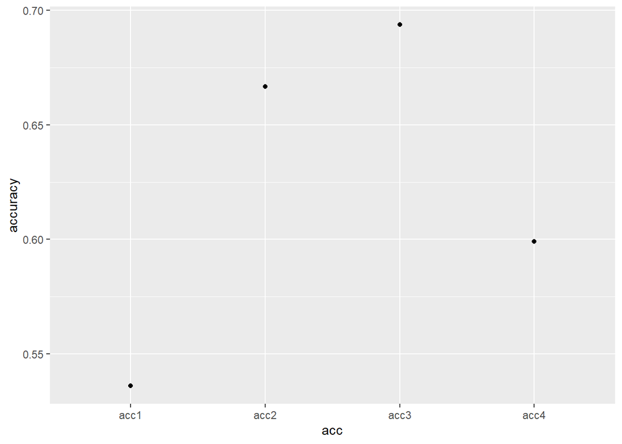

```r
acc <- data.frame(acc1, acc2, acc3, acc4)
acc <- acc%>%gather(key=acc, value=accuracy)
acc%>%ggplot(aes(acc, accuracy))+geom_point()
```

k가 1일 때 이외에는 정확도가 수시로 변해 어느 k값이 더 좋은지 단정지을 수 없으며, 정확도가 60%정도로 매우 낮음.

voice 데이터의 SVM과 k-NN 모델 voice 데이터로 모델링을 하기 위해 전처리

```r
voice <- read.csv("voice.csv")
table(is.na(voice))
```

```
##
## FALSE
## 66528
```

```r
voice$label <- as.factor(voice$label)
```

voice의 SVM

```r
s <- svm(label~., data=voice)
acc <- table(predict(s, voice), voice$label)
acc1 <- sum(acc["female", "female"]+acc["male", "male"])/sum(acc)
acc
```

```
##
##          female male
##   female   1565   29
##   male       19 1555
```

```r
acc1
```

```
## [1] 0.9848485
```

```r
s <- svm(label~., data=voice, kernal="polynomial")
acc <- table(predict(s, voice), voice$label)
acc2 <- sum(acc["female", "female"]+acc["male", "male"])/sum(acc)
acc
```

```
##
##          female male
##   female   1565   29
##   male       19 1555
```

```r
acc2
```

```
## [1] 0.9848485
```

```r
s <- svm(label~., data=voice, cost=100)
acc <- table(predict(s, voice), voice$label)
acc3 <- sum(acc["female", "female"]+acc["male", "male"])/sum(acc)
acc
```

```
##
##          female male
##   female   1584    0
##   male        0 1584
```

```r
acc3
```

```
## [1] 1
```

```r
s <- svm(label~., data=voice, kernal="polynomial", cost=100)
acc <- table(predict(s, voice), voice$label)
acc4<- sum(acc["female", "female"]+acc["male", "male"])/sum(acc)
acc
```

```
##
##          female male
##   female   1584    0
##   male        0 1584
```

```r
acc4
```

```
## [1] 1
```

각 SVM의 정확도를 데이터 프레임으로 만들어 시각화, 평가

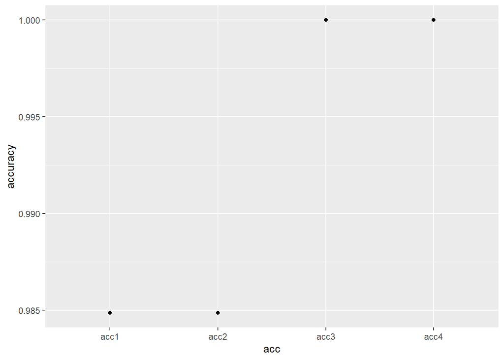

```r
accuracy <- data.frame(acc1, acc2, acc3, acc4)
accuracy <- accuracy%>%gather(key=acc, value=accuracy)
accuracy%>%ggplot(aes(acc, accuracy))+geom_point()
```

voice의 SVM의 정확도는 커널의 종류와 관계 없으며, cost를 100으로 설정했을 때 모든 오류가 사라지는 것을 확인할 수 있음

voice의 k-NN

```r
test <- voice
n=3168
voice1 <- sample(1:n, size=2/3*n)
voice_train <- voice[voice1, -21]
voice_test <- voice[-voice1, -21]
trainLabels <- voice[voice1, 21]
testLabels <- voice[-voice1, 21]
k1 <- knn(voice_train, voice_test, trainLabels, k=1)
acc1 <- sum(k1==testLabels)/1056
k2 <- knn(voice_train, voice_test, trainLabels, k=5)
acc2 <- sum(k2==testLabels)/1056
k3 <- knn(voice_train, voice_test, trainLabels, k=10)
acc3 <- sum(k3==testLabels)/1056
k4 <- knn(voice_train, voice_test, trainLabels, k=100)
acc4 <- sum(k4==testLabels)/1056
```

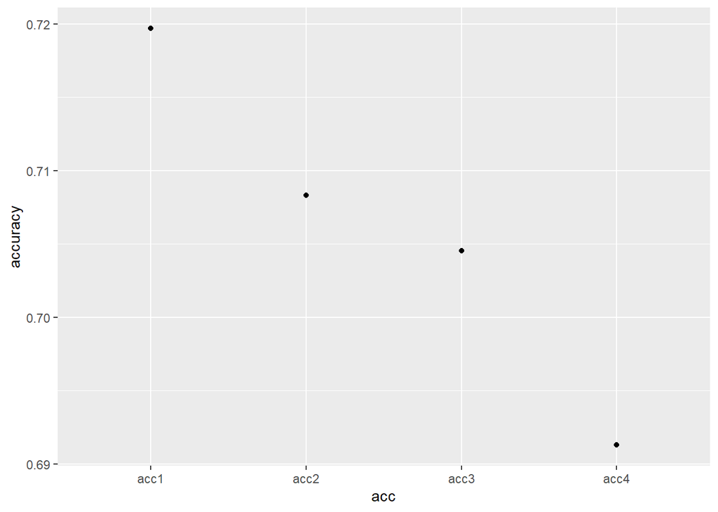

```r
accuracy <- data.frame(acc1, acc2, acc3, acc4)
accuracy <- accuracy%>%gather(key=acc, value=accuracy)
accuracy%>%ggplot(aes(acc, accuracy))+geom_point()
```